# Completed_FullCode_Employee_Promotion_Prediction_Project_3

## Problem Statement

### Business context

Employee Promotion means the ascension of an employee to higher ranks, this aspect of the job is what drives employees the most. The ultimate reward for dedication and loyalty towards an organization and the HR team plays an important role in handling all these promotion tasks based on ratings and other attributes available.

The HR team in JMD company stored data on the promotion cycle last year, which consists of details of all the employees in the company working last year and also if they got promoted or not, but every time this process gets delayed due to so many details available for each employee - it gets difficult to compare and decide.

### Objective

For the upcoming appraisal cycle, the HR team wants to utilize the stored data and leverage machine learning to make a model that will predict if a person is eligible for promotion or not. You, as a data scientist at JMD company, need to come up with the best possible model that will help the HR team to predict if a person is eligible for promotion or not.

### Data Description

- employee_id: Unique ID for the employee
- department: Department of employee
- region: Region of employment (unordered)
- education: Education Level
- gender: Gender of Employee
- recruitment_channel: Channel of recruitment for employee
- no_ of_ trainings: no of other training completed in the previous year on soft skills, technical skills, etc.
- age: Age of Employee
- previous_ year_ rating: Employee Rating for the previous year
- length_ of_ service: Length of service in years
- awards_ won: if awards won during the previous year then 1 else 0
- avg_ training_ score: Average score in current training evaluations
- is_promoted: (Target) Recommended for promotion

## Importing necessary libraries

```python
# Installing the libraries with the specified version.
# uncomment and run the following line if Google Colab is being used
!pip install scikit-learn==1.2.2 seaborn matplotlib==3.9.0 numpy==1.26.4 pandas==2.2.2 imbalanced-learn==0.10.1 xgboost==2.0.3  --user --no-cache-dir --force-reinstall
```

[output not shown]

[output cut: 79 more lines]

[output not shown]

```python
from google.colab import drive
drive.mount('/content/drive')
```

```python
!jupyter nbconvert  '/content/drive/MyDrive/AIML-UTAustin/Project 3_Employee Promotion Prediction/Completed_FullCode_Employee_Promotion_Prediction_Project_AML.ipynb' --to html
```

```
[NbConvertApp] Converting notebook /content/drive/MyDrive/AIML-UTAustin/Project 3_Employee Promotion Prediction/Completed_FullCode_Employee_Promotion_Prediction_Project_AML.ipynb to html
[NbConvertApp] WARNING | Alternative text is missing on 28 image(s).
[NbConvertApp] Writing 2232308 bytes to /content/drive/MyDrive/AIML-UTAustin/Project 3_Employee Promotion Prediction/Completed_FullCode_Employee_Promotion_Prediction_Project_AML.html
```

```python
# Libraries to help with reading and manipulating data
import seaborn as sns
import pandas as pd
import numpy as np

# Libaries to help with data visualization
import matplotlib.pyplot as plt
```

```python
# To tune model, get different metric scores, and split data
from sklearn.metrics import (
    f1_score,
    accuracy_score,
    recall_score,
    precision_score,
    confusion_matrix,
    roc_auc_score,
    ConfusionMatrixDisplay
)
from sklearn.model_selection import train_test_split, StratifiedKFold, cross_val_score
```

```python
# To be used for data scaling and one hot encoding
from sklearn.preprocessing import StandardScaler, MinMaxScaler, OneHotEncoder

# To oversample and undersample data
from imblearn.over_sampling import SMOTE
from imblearn.under_sampling import RandomUnderSampler

# To do hyperparameter tuning
from sklearn.model_selection import RandomizedSearchCV

# To impute missing values
from sklearn.impute import SimpleImputer

# To define maximum number of columns to be displayed in a dataframe
pd.set_option("display.max_columns", None)

# To supress scientific notations for a dataframe
pd.set_option("display.float_format", lambda x: "%.3f" % x)
```

```python
# To help with model building
from sklearn.tree import DecisionTreeClassifier
from sklearn.ensemble import (
    AdaBoostClassifier,
    GradientBoostingClassifier,
    RandomForestClassifier,
    BaggingClassifier,
)
from xgboost import XGBClassifier

# To suppress scientific notations
pd.set_option("display.float_format", lambda x: "%.3f" % x)

# To supress warnings
import warnings

warnings.filterwarnings("ignore")
```

## Loading the dataset

```python
promotion = pd.read_csv('/content/drive/MyDrive/AIML-UTAustin/Project 3_Employee Promotion Prediction/employee_promotion.csv')
```

## Data Overview

- Observations
- Sanity checks

```python
promotion.info()
```

```
<class 'pandas.core.frame.DataFrame'>
RangeIndex: 54808 entries, 0 to 54807
Data columns (total 13 columns):
 #   Column                Non-Null Count  Dtype
---  ------                --------------  -----
 0   employee_id           54808 non-null  int64
 1   department            54808 non-null  object
 2   region                54808 non-null  object
 3   education             52399 non-null  object
 4   gender                54808 non-null  object
 5   recruitment_channel   54808 non-null  object
 6   no_of_trainings       54808 non-null  int64
 7   age                   54808 non-null  int64
 8   previous_year_rating  50684 non-null  float64
 9   length_of_service     54808 non-null  int64
 10  awards_won            54808 non-null  int64
 11  avg_training_score    52248 non-null  float64
 12  is_promoted           54808 non-null  int64
dtypes: float64(2), int64(6), object(5)
memory usage: 5.4+ MB
```

```python
data = promotion.copy()
```

```python
data.head()
```

|  | employee_id | department | region | education | gender | recruitment_channel | no_of_trainings | age | previous_year_rating | length_of_service | awards_won | avg_training_score | is_promoted |
| --- | --- | --- | --- | --- | --- | --- | --- | --- | --- | --- | --- | --- | --- |
| 0 | 65438 | Sales & Marketing | region_7 | Master's & above | f | sourcing | 1 | 35 | 5.000 | 8 | 0 | 49.000 | 0 |
| 1 | 65141 | Operations | region_22 | Bachelor's | m | other | 1 | 30 | 5.000 | 4 | 0 | 60.000 | 0 |
| 2 | 7513 | Sales & Marketing | region_19 | Bachelor's | m | sourcing | 1 | 34 | 3.000 | 7 | 0 | 50.000 | 0 |
| 3 | 2542 | Sales & Marketing | region_23 | Bachelor's | m | other | 2 | 39 | 1.000 | 10 | 0 | 50.000 | 0 |
| 4 | 48945 | Technology | region_26 | Bachelor's | m | other | 1 | 45 | 3.000 | 2 | 0 | 73.000 | 0 |

```python
data.tail()
```

|  | employee_id | department | region | education | gender | recruitment_channel | no_of_trainings | age | previous_year_rating | length_of_service | awards_won | avg_training_score | is_promoted |
| --- | --- | --- | --- | --- | --- | --- | --- | --- | --- | --- | --- | --- | --- |
| 54803 | 3030 | Technology | region_14 | Bachelor's | m | sourcing | 1 | 48 | 3.000 | 17 | 0 | 78.000 | 0 |
| 54804 | 74592 | Operations | region_27 | Master's & above | f | other | 1 | 37 | 2.000 | 6 | 0 | 56.000 | 0 |
| 54805 | 13918 | Analytics | region_1 | Bachelor's | m | other | 1 | 27 | 5.000 | 3 | 0 | 79.000 | 0 |
| 54806 | 13614 | Sales & Marketing | region_9 | NaN | m | sourcing | 1 | 29 | 1.000 | 2 | 0 | NaN | 0 |
| 54807 | 51526 | HR | region_22 | Bachelor's | m | other | 1 | 27 | 1.000 | 5 | 0 | 49.000 | 0 |

```python
#statistical summary of data
data.describe()
```

|  | employee_id | no_of_trainings | age | previous_year_rating | length_of_service | awards_won | avg_training_score | is_promoted |
| --- | --- | --- | --- | --- | --- | --- | --- | --- |
| count | 54808.000 | 54808.000 | 54808.000 | 50684.000 | 54808.000 | 54808.000 | 52248.000 | 54808.000 |
| mean | 39195.831 | 1.253 | 34.804 | 3.329 | 5.866 | 0.023 | 63.712 | 0.085 |
| std | 22586.581 | 0.609 | 7.660 | 1.260 | 4.265 | 0.150 | 13.522 | 0.279 |
| min | 1.000 | 1.000 | 20.000 | 1.000 | 1.000 | 0.000 | 39.000 | 0.000 |
| 25% | 19669.750 | 1.000 | 29.000 | 3.000 | 3.000 | 0.000 | 51.000 | 0.000 |
| 50% | 39225.500 | 1.000 | 33.000 | 3.000 | 5.000 | 0.000 | 60.000 | 0.000 |
| 75% | 58730.500 | 1.000 | 39.000 | 4.000 | 7.000 | 0.000 | 77.000 | 0.000 |
| max | 78298.000 | 10.000 | 60.000 | 5.000 | 37.000 | 1.000 | 99.000 | 1.000 |

```python
data.isnull().sum()
```

|  | 0 |
| --- | --- |
| employee_id | 0 |
| department | 0 |
| region | 0 |
| education | 2409 |
| gender | 0 |
| recruitment_channel | 0 |
| no_of_trainings | 0 |
| age | 0 |
| previous_year_rating | 4124 |
| length_of_service | 0 |
| awards_won | 0 |
| avg_training_score | 2560 |
| is_promoted | 0 |

**dtype:** int64

```python
# Missing Data Count per column
data.isna().sum()
```

|  | 0 |
| --- | --- |
| employee_id | 0 |
| department | 0 |
| region | 0 |
| education | 2409 |
| gender | 0 |
| recruitment_channel | 0 |
| no_of_trainings | 0 |
| age | 0 |
| previous_year_rating | 4124 |
| length_of_service | 0 |
| awards_won | 0 |
| avg_training_score | 2560 |
| is_promoted | 0 |

**dtype:** int64

```python
# Total missing values
data.isnull().sum().sum()
```

```
9093
```

```python
# Rows with missing Data
data[data.isnull().any(axis=1)]
```

|  | employee_id | department | region | education | gender | recruitment_channel | no_of_trainings | age | previous_year_rating | length_of_service | awards_won | avg_training_score | is_promoted |
| --- | --- | --- | --- | --- | --- | --- | --- | --- | --- | --- | --- | --- | --- |
| 10 | 29934 | Technology | region_23 | NaN | m | sourcing | 1 | 30 | NaN | 1 | 0 | 77.000 | 0 |
| 21 | 33332 | Operations | region_15 | NaN | m | sourcing | 1 | 41 | 4.000 | 11 | 0 | 57.000 | 0 |
| 23 | 71177 | Procurement | region_5 | Bachelor's | m | other | 1 | 27 | NaN | 1 | 0 | 70.000 | 0 |
| 29 | 74759 | Sales & Marketing | region_4 | Bachelor's | m | sourcing | 1 | 26 | NaN | 1 | 0 | 44.000 | 0 |
| 31 | 58536 | Finance | region_31 | Bachelor's | m | other | 2 | 26 | 1.000 | 2 | 0 | NaN | 0 |
| ... | ... | ... | ... | ... | ... | ... | ... | ... | ... | ... | ... | ... | ... |
| 54742 | 38935 | Sales & Marketing | region_31 | NaN | m | other | 1 | 28 | 4.000 | 3 | 0 | 47.000 | 0 |
| 54746 | 10546 | Finance | region_6 | Bachelor's | m | other | 1 | 28 | NaN | 1 | 0 | NaN | 0 |
| 54773 | 37919 | Finance | region_2 | Bachelor's | m | other | 1 | 23 | NaN | 1 | 0 | NaN | 0 |
| 54801 | 12431 | Technology | region_26 | Bachelor's | f | sourcing | 1 | 31 | NaN | 1 | 0 | 78.000 | 0 |
| 54806 | 13614 | Sales & Marketing | region_9 | NaN | m | sourcing | 1 | 29 | 1.000 | 2 | 0 | NaN | 0 |

8428 rows × 13 columns

```python
# Count Duplicate Rows
data.duplicated().sum()
```

```
0
```

```python
#check number of unique values in each column
data.nunique()
```

|  | 0 |
| --- | --- |
| employee_id | 54808 |
| department | 9 |
| region | 34 |
| education | 3 |
| gender | 2 |
| recruitment_channel | 3 |
| no_of_trainings | 10 |
| age | 41 |
| previous_year_rating | 5 |
| length_of_service | 35 |
| awards_won | 2 |
| avg_training_score | 59 |
| is_promoted | 2 |

**dtype:** int64

```python
#number of rows and columns
data.shape
```

```
(54808, 13)
```

```python
for i in data.describe(include=["object"]).columns:
    print("Unique values in", i, "are :")
    print(data[i].value_counts())
    print("*" * 50)
```

```
Unique values in department are :
department
Sales & Marketing    16840
Operations           11348
Technology            7138
Procurement           7138
Analytics             5352
Finance               2536
HR                    2418
Legal                 1039
R&D                    999
Name: count, dtype: int64
Unique values in region are :
region
region_2     12343
region_22     6428
region_7      4843
region_15     2808
region_13     2648
region_26     2260
region_31     1935
region_4      1703
region_27     1659
region_16     1465
region_28     1318
region_11     1315
region_23     1175
region_29      994
region_32      945
region_19      874
region_20      850
region_14      827
region_25      819
region_17      796
region_5       766
region_6       690
region_30      657
region_8       655
region_10      648
region_1       610
```

[output cut: 11 more lines]

```
Bachelor's          36669
Master's & above    14925
Below Secondary       805
Name: count, dtype: int64
Unique values in gender are :
gender
m    38496
f    16312
Name: count, dtype: int64
Unique values in recruitment_channel are :
recruitment_channel
other       30446
sourcing    23220
referred     1142
Name: count, dtype: int64
```

```python
# ID column consists of uniques ID for clients and hence will not add value to the modeling
data.drop(columns="employee_id", inplace=True)
```

```python
data["is_promoted"].value_counts(1)
```

| is_promoted | proportion |
| --- | --- |
| 0 | 0.915 |
| 1 | 0.085 |

**dtype:** float64

## Exploratory Data Analysis (EDA)

- EDA is an important part of any project involving data.
- It is important to investigate and understand the data better before building a model with it.
- A few questions have been mentioned below which will help you approach the analysis in the right manner and generate insights from the data.
- A thorough analysis of the data, in addition to the questions mentioned below, should be done.

**Questions**:

1. How is the distribution of average training score of employee ?
2. How is the distribution age of employee ?
3. How does the change in length of service (`length_of_service`) vary by the employee's promotion status (`is_promoted`)?
4. How does the previous rating(`previous_year_rating`) vary by the employee's promotion status (`is_promoted`)?
5. What are the attributes that have a strong correlation with each other?

#### The below functions need to be defined to carry out the Exploratory Data Analysis.

```python
# function to plot a boxplot and a histogram along the same scale.


def histogram_boxplot(data, feature, figsize=(12, 7), kde=False, bins=None):
    """
    Boxplot and histogram combined

    data: dataframe
    feature: dataframe column
    figsize: size of figure (default (12,7))
    kde: whether to the show density curve (default False)
    bins: number of bins for histogram (default None)
    """
    f2, (ax_box2, ax_hist2) = plt.subplots(
        nrows=2,  # Number of rows of the subplot grid= 2
        sharex=True,  # x-axis will be shared among all subplots
        gridspec_kw={"height_ratios": (0.25, 0.75)},
        figsize=figsize,
    )  # creating the 2 subplots
    sns.boxplot(
        data=data, x=feature, ax=ax_box2, showmeans=True, color="violet"
    )  # boxplot will be created and a triangle will indicate the mean value of the column
    sns.histplot(
        data=data, x=feature, kde=kde, ax=ax_hist2, bins=bins, palette="winter"
    ) if bins else sns.histplot(
        data=data, x=feature, kde=kde, ax=ax_hist2
    )  # For histogram
    ax_hist2.axvline(
        data[feature].mean(), color="green", linestyle="--"
    )  # Add mean to the histogram
    ax_hist2.axvline(
        data[feature].median(), color="black", linestyle="-"
    )  # Add median to the histogram
```

```python
# function to create labeled barplots


def labeled_barplot(data, feature, perc=False, n=None):
    """
    Barplot with percentage at the top

    data: dataframe
    feature: dataframe column
    perc: whether to display percentages instead of count (default is False)
    n: displays the top n category levels (default is None, i.e., display all levels)
    """

    total = len(data[feature])  # length of the column
    count = data[feature].nunique()
    if n is None:
        plt.figure(figsize=(count + 1, 5))
    else:
        plt.figure(figsize=(n + 1, 5))

    plt.xticks(rotation=90, fontsize=15)
    ax = sns.countplot(
        data=data,
        x=feature,
        palette="Paired",
        order=data[feature].value_counts().index[:n].sort_values(),
    )

    for p in ax.patches:
        if perc == True:
            label = "{:.1f}%".format(
                100 * p.get_height() / total
            )  # percentage of each class of the category
        else:
            label = p.get_height()  # count of each level of the category

        x = p.get_x() + p.get_width() / 2  # width of the plot
        y = p.get_height()  # height of the plot

        ax.annotate(
            label,
            (x, y),
            ha="center",
            va="center",
            size=12,
            xytext=(0, 5),
            textcoords="offset points",
        )  # annotate the percentage

    plt.show()  # show the plot
```

```python
# function to plot stacked bar chart

def stacked_barplot(data, predictor, target):
    """
    Print the category counts and plot a stacked bar chart

    data: dataframe
    predictor: independent variable
    target: target variable
    """
    count = data[predictor].nunique()
    sorter = data[target].value_counts().index[-1]
    tab1 = pd.crosstab(data[predictor], data[target], margins=True).sort_values(
        by=sorter, ascending=False
    )
    print(tab1)
    print("-" * 120)
    tab = pd.crosstab(data[predictor], data[target], normalize="index").sort_values(
        by=sorter, ascending=False
    )
    tab.plot(kind="bar", stacked=True, figsize=(count + 1, 5))
    plt.legend(
        loc="lower left", frameon=False,
    )
    plt.legend(loc="upper left", bbox_to_anchor=(1, 1))
    plt.show()
```

```python
### Function to plot distributions

def distribution_plot_wrt_target(data, predictor, target):

    fig, axs = plt.subplots(2, 2, figsize=(12, 10))

    target_uniq = data[target].unique()

    axs[0, 0].set_title("Distribution of target for target=" + str(target_uniq[0]))
    sns.histplot(
        data=data[data[target] == target_uniq[0]],
        x=predictor,
        kde=True,
        ax=axs[0, 0],
        color="teal",
    )

    axs[0, 1].set_title("Distribution of target for target=" + str(target_uniq[1]))
    sns.histplot(
        data=data[data[target] == target_uniq[1]],
        x=predictor,
        kde=True,
        ax=axs[0, 1],
        color="orange",
    )

    axs[1, 0].set_title("Boxplot w.r.t target")
    sns.boxplot(data=data, x=target, y=predictor, ax=axs[1, 0], palette="gist_rainbow")

    axs[1, 1].set_title("Boxplot (without outliers) w.r.t target")
    sns.boxplot(
        data=data,
        x=target,
        y=predictor,
        ax=axs[1, 1],
        showfliers=False,
        palette="gist_rainbow",
    )

    plt.tight_layout()
    plt.show()
```

Univariate analysis

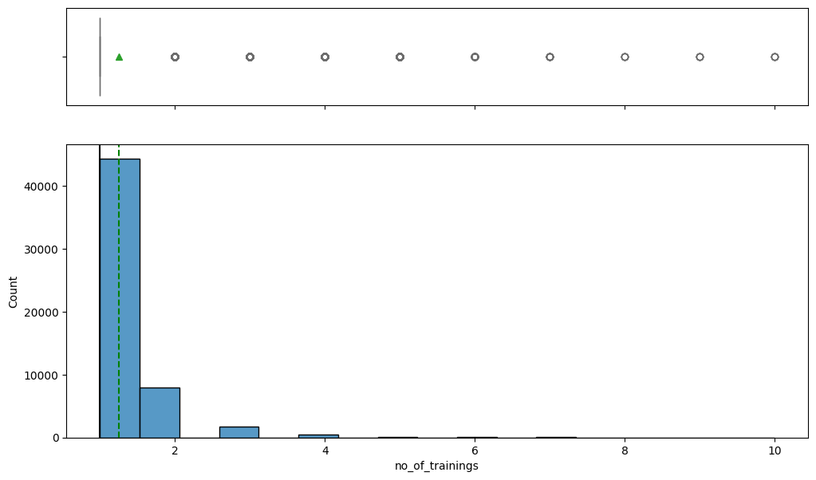

```python
# Observations on No. of Trainings
histogram_boxplot(data, "no_of_trainings")
```

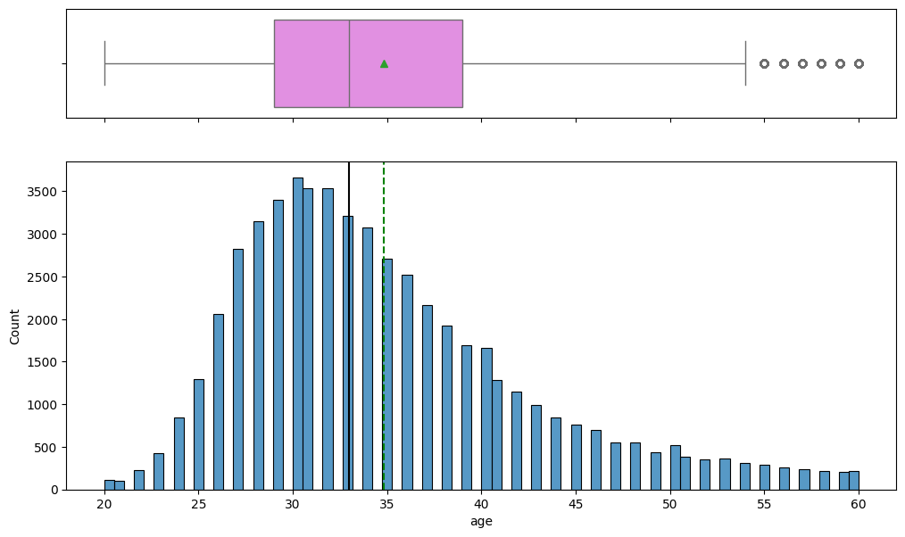

```python
# Observations on Age
histogram_boxplot(data, "age")
```

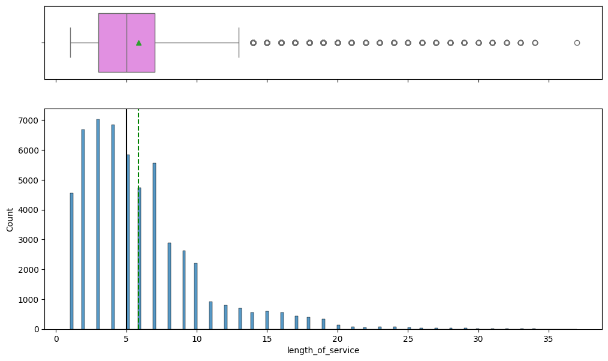

```python
# Observations on Length of Service
histogram_boxplot(data, "length_of_service")
```

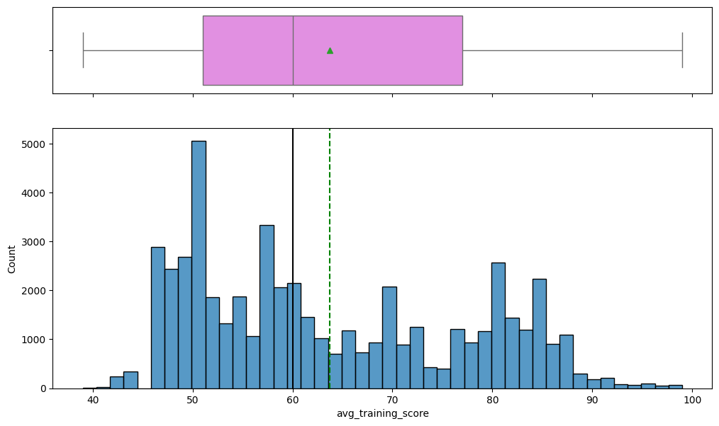

```python
# Observations on Average Training Score
histogram_boxplot(data, "avg_training_score")
```

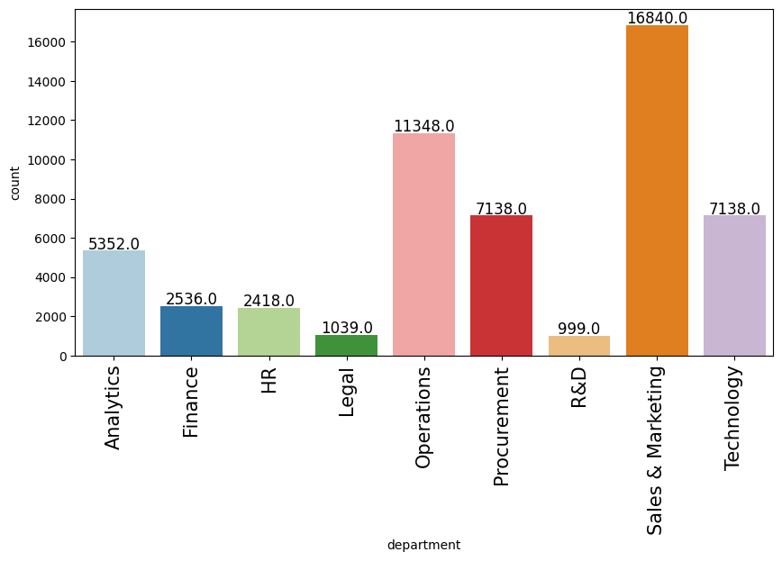

```python
# Observations on Department
labeled_barplot(data, "department")
```

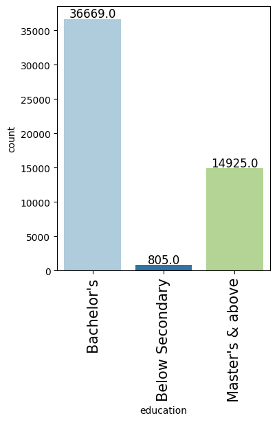

```python
# Observations on Education
labeled_barplot(data, "education")
```

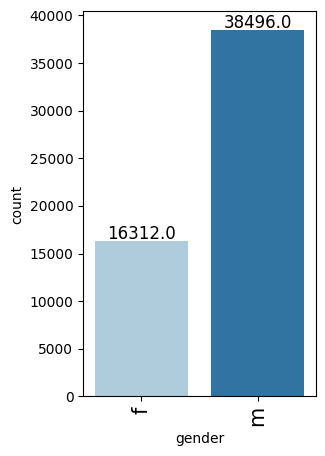

```python
# Observations on Gender
labeled_barplot(data, "gender")
```

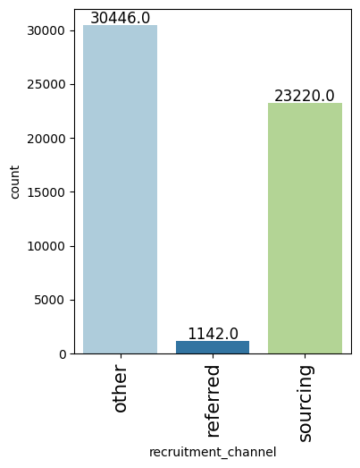

```python
# Observations on Recruitment Channel
labeled_barplot(data, "recruitment_channel")
```

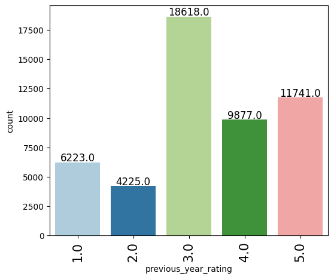

```python
# Observations on Previous Year Rating
labeled_barplot(data, "previous_year_rating")
```

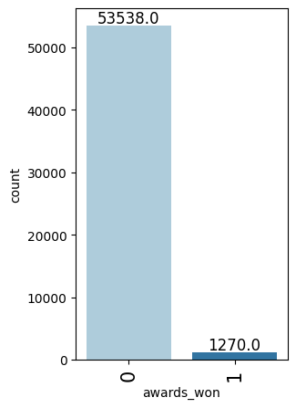

```python
# Observations on Awards Won
labeled_barplot(data, "awards_won")
```

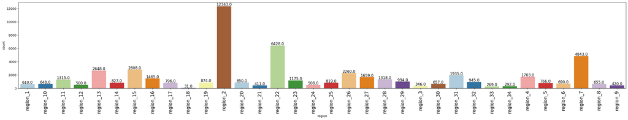

```python
# Observations on Region
labeled_barplot(data, "region")
```

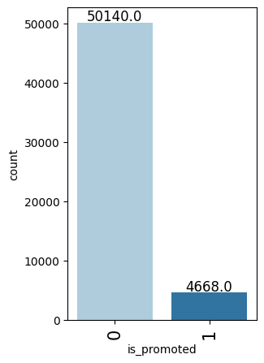

```python
# Observations on target
labeled_barplot(data, "is_promoted")
```

Bivariate Analysis

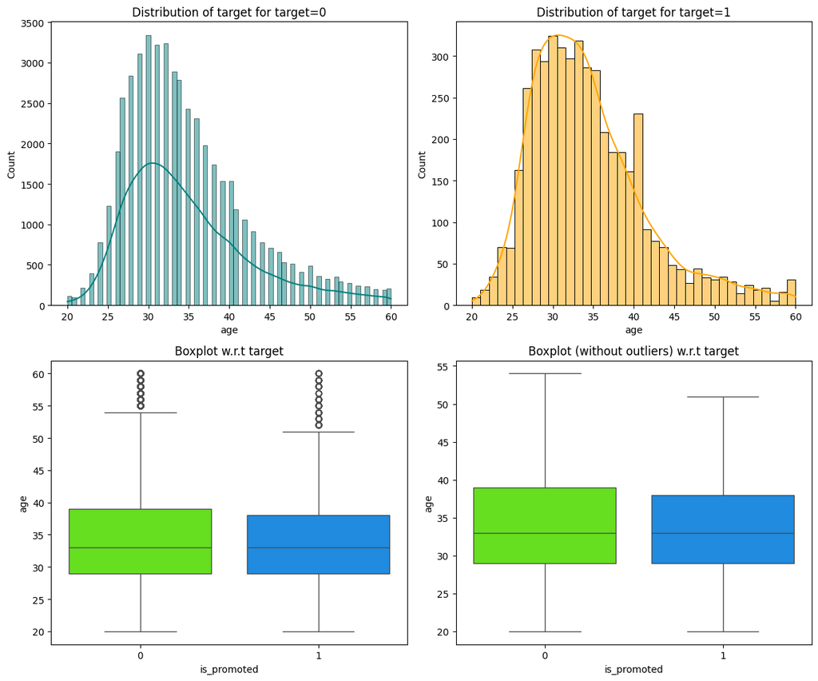

```python
# Target variable (is_promoted) vs Age
distribution_plot_wrt_target(data, "age", "is_promoted")
```

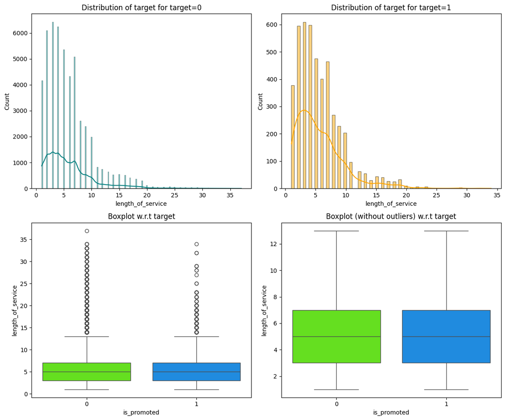

```python
# is_promoted vs Length of Service
distribution_plot_wrt_target(data, "length_of_service", "is_promoted")
```

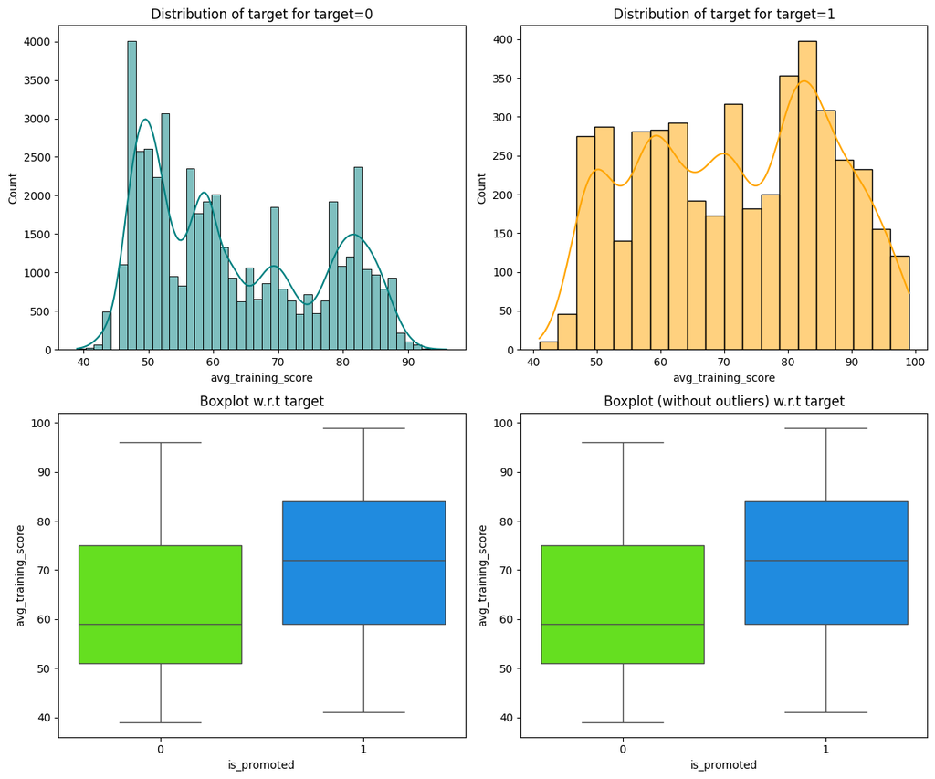

```python
# Target variable (is_promoted) vs Average Training Score
distribution_plot_wrt_target(data, "avg_training_score", "is_promoted")
```

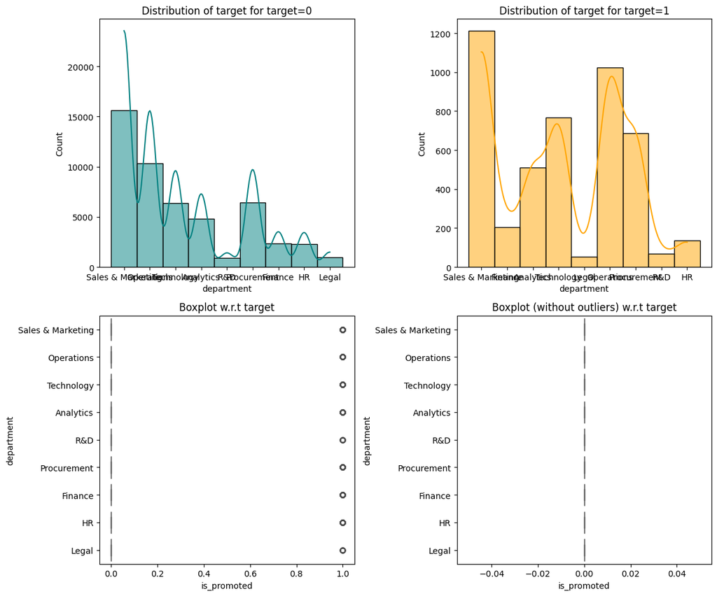

```python
# Target variable (is_promoted) vs Department
distribution_plot_wrt_target(data, "department", "is_promoted")
```

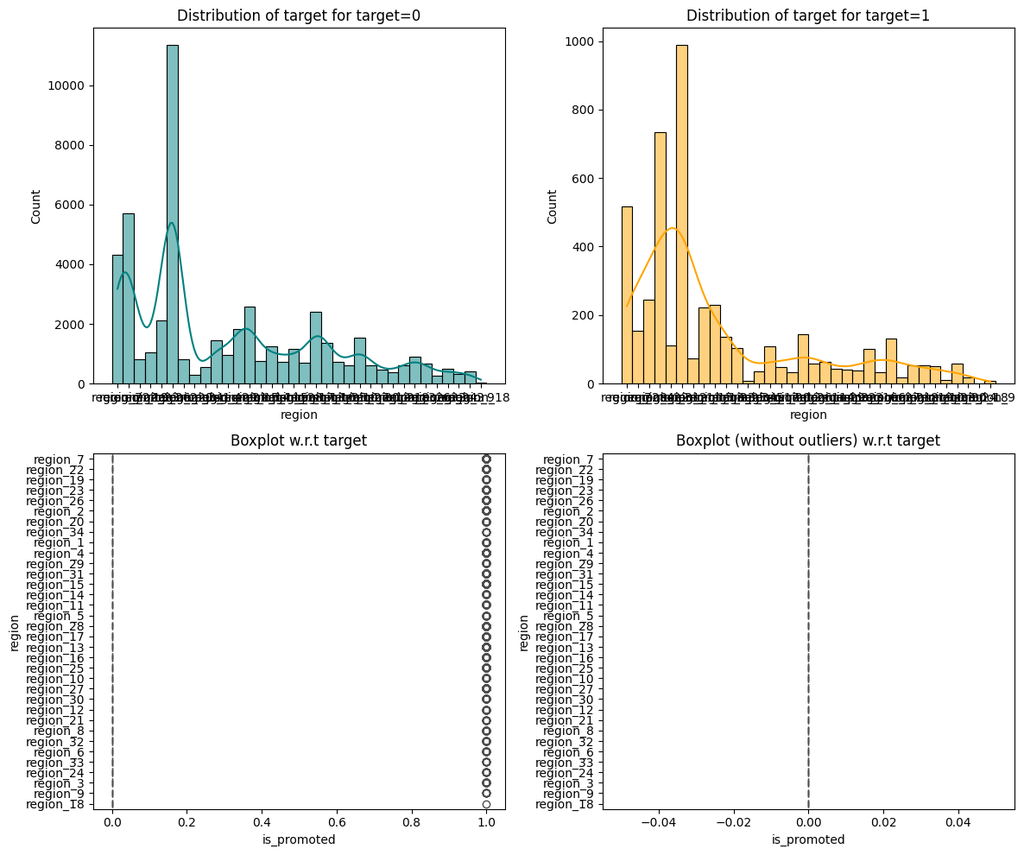

```python
# Target variable (is_promoted) vs Region
distribution_plot_wrt_target(data, "region", "is_promoted")
```

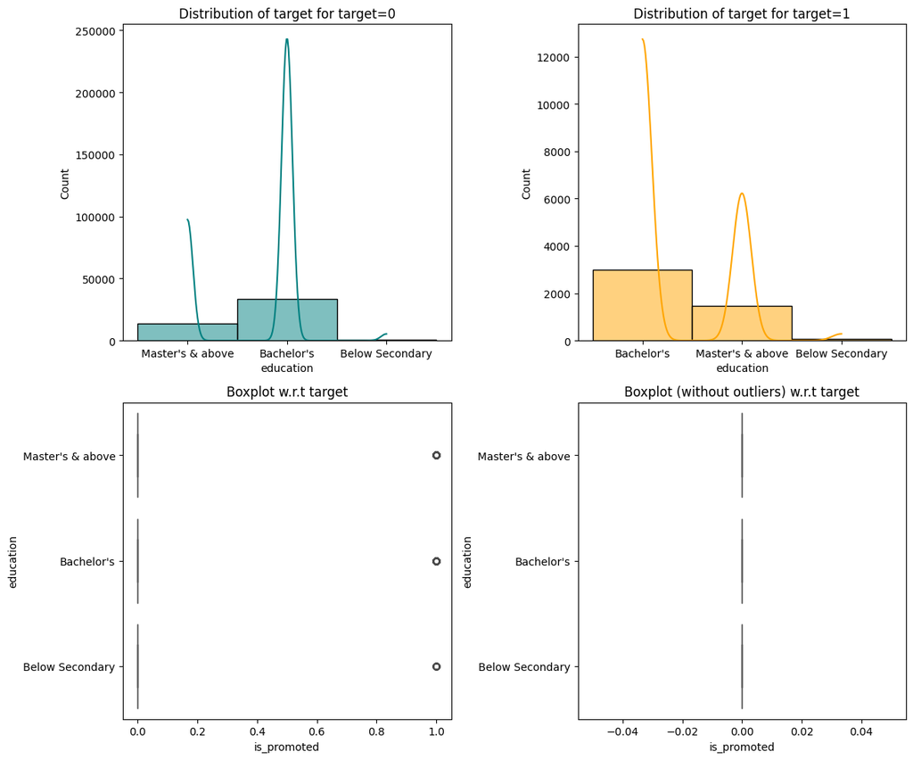

```python
# Target variable (is_promoted) vs Education
distribution_plot_wrt_target(data, "education", "is_promoted")
```

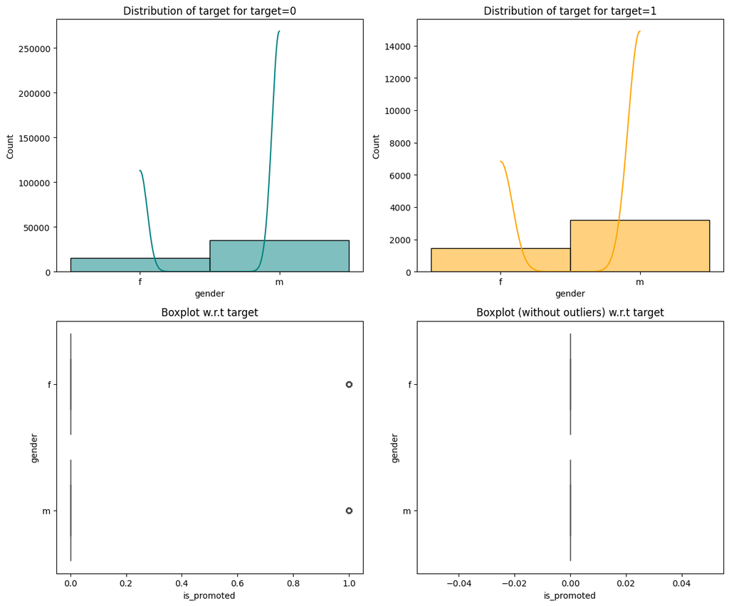

```python
# Target variable (is_promoted) vs Gender
distribution_plot_wrt_target(data, "gender", "is_promoted")
```

```
is_promoted              0     1    All
recruitment_channel
All                  50140  4668  54808
other                27890  2556  30446
sourcing             21246  1974  23220
referred              1004   138   1142
------------------------------------------------------------------------------------------------------------------------
```

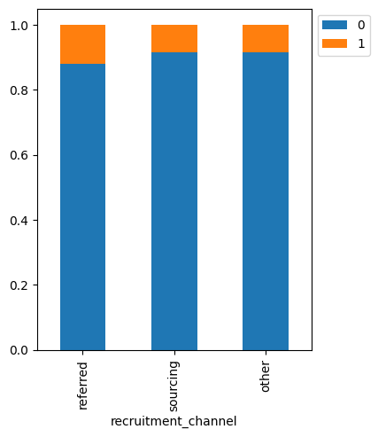

```python
# Target variable (is_promoted) vs Recruitment Channel
stacked_barplot(data, "recruitment_channel", "is_promoted")
```

```
is_promoted               0     1    All
previous_year_rating
 All                  46355  4329  50684
5.000                  9820  1921  11741
3.000                 17263  1355  18618
4.000                  9093   784   9877
2.000                  4044   181   4225
1.000                  6135    88   6223
------------------------------------------------------------------------------------------------------------------------
```

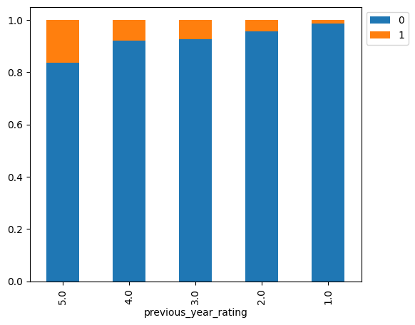

```python
# Target variable (is_promoted) vs Previous Year Rating
stacked_barplot(data, "previous_year_rating", "is_promoted")
```

```
is_promoted      0     1    All
awards_won
All          50140  4668  54808
0            49429  4109  53538
1              711   559   1270
------------------------------------------------------------------------------------------------------------------------
```

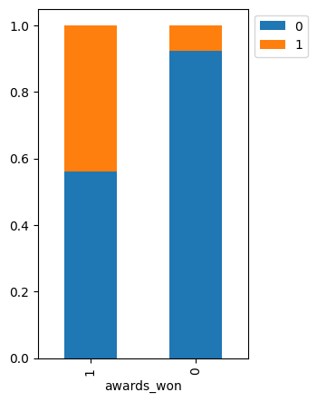

```python
# Target variable (is_promoted) vs Awards Won
stacked_barplot(data, "awards_won", "is_promoted")
```

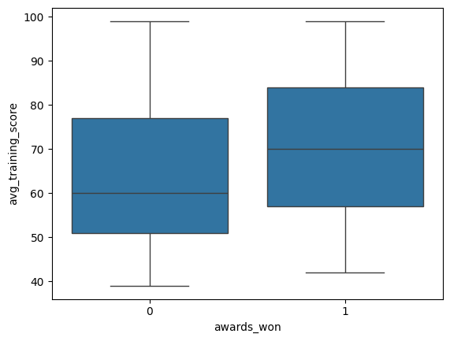

```python
sns.boxplot(data=data, x="awards_won", y="avg_training_score")
```

Let's see the attributes that have a strong correlation with each other

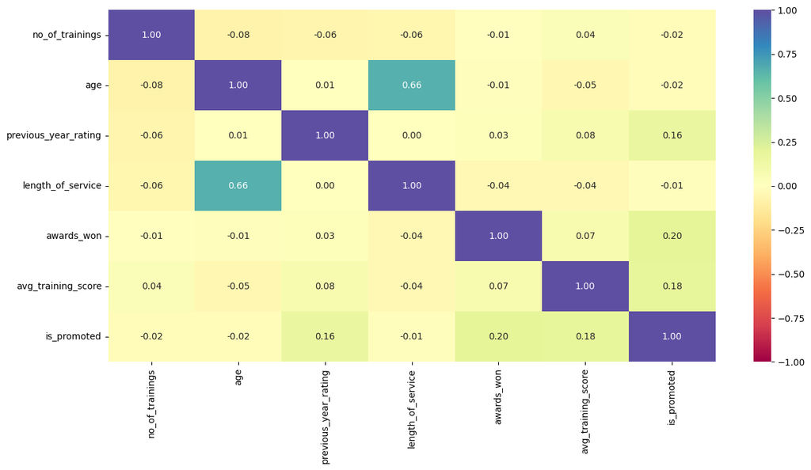

```python
# Correlation Heatmap
plt.figure(figsize=(15, 7))
sns.heatmap(data.corr(numeric_only = True), annot=True, vmin=-1, vmax=1, fmt=".2f", cmap="Spectral")
plt.show()
```

## Data Pre-processing

```python
data1 = data.copy()
```

```python
#Train-Test Split
X = data1.drop(["is_promoted"], axis=1)
y = data1["is_promoted"]

# Splitting data into training and validation set in the ratio 80:20
X_train, X_temp, y_train, y_temp = train_test_split(
    X, y, test_size=0.2, random_state=5, stratify=y)

# Split the data into train test in the ratio 75:25
X_test, X_val, y_test, y_val = train_test_split(
    X_temp, y_temp, test_size=0.25, random_state=5, stratify=y_temp)
print(X_train.shape, X_val.shape, X_test.shape)
```

```
(43846, 11) (2741, 11) (8221, 11)
```

# Missing value imputation

```python
# Defining the imputers for numerical and categorical variables
imputer_mode = SimpleImputer(strategy="most_frequent")
imputer_median = SimpleImputer(strategy="median")
```

```python
# Impute data for Education
# Fit and transform the train data
X_train[["education"]] = imputer_mode.fit_transform(X_train[["education"]])

# Transform the validation data to impute missing values in X_val
X_val[["education"]]  =  imputer_mode.fit_transform(X_val[["education"]])

# Transform the test data to impute missing values in X_test
X_test[["education"]] =  imputer_mode.fit_transform(X_test[["education"]])
```

```python
# Impute Dat for previous year rating and average training score
# Fit and transform the train data
X_train[["previous_year_rating", "avg_training_score"]] = imputer_median.fit_transform(
    X_train[["previous_year_rating", "avg_training_score"]]
)

# Transform the validation data
X_val[["previous_year_rating", "avg_training_score"]]  =  imputer_median.fit_transform(
    X_val[["previous_year_rating", "avg_training_score"]]
)
# Transform the test data
X_test[["previous_year_rating", "avg_training_score"]] = imputer_median.fit_transform(
    X_test[["previous_year_rating", "avg_training_score"]]
)
```

```python
# Checking that no column has missing values in train, validation and test sets
print(X_train.isna().sum())
print("=" * 30)
print(X_val.isna().sum())
print("=" * 30)
print(X_test.isna().sum())
```

```
department              0
region                  0
education               0
gender                  0
recruitment_channel     0
no_of_trainings         0
age                     0
previous_year_rating    0
length_of_service       0
awards_won              0
avg_training_score      0
dtype: int64
==============================
department              0
region                  0
education               0
gender                  0
recruitment_channel     0
no_of_trainings         0
age                     0
previous_year_rating    0
length_of_service       0
awards_won              0
avg_training_score      0
dtype: int64
==============================
department              0
region                  0
education               0
gender                  0
recruitment_channel     0
no_of_trainings         0
age                     0
previous_year_rating    0
length_of_service       0
awards_won              0
avg_training_score      0
dtype: int64
```

### Encoding categorical variables

```python
X_train = pd.get_dummies(X_train, drop_first=True)
X_train = X_train.astype(float)

X_val = pd.get_dummies(X_val, drop_first=True)
X_val = X_val.astype(float)

X_test = pd.get_dummies(X_test, drop_first=True)
X_test = X_test.astype(float)

print(X_train.shape, X_val.shape, X_test.shape)
```

```
(43846, 52) (2741, 52) (8221, 52)
```

## Model Building

### Model evaluation criterion

The nature of predictions made by the classification model will translate as follows:

**Which metric to optimize?**

**Model can make wrong predictions as:**

- Predicting an employee should get promoted when he/she should not get promoted Predicting an employee should not get promoted when he/she should get promoted

**Which case is more important?**

- Both cases are important here as not promoting a deserving employee might lead to less productivity and the company might lose a good employee which affects the company's growth. Further, giving promotion to a non-deserving employee would lead to loss of monetary resources and giving such employee higher responsibility might again affect the company's growth.

**How to reduce this loss i.e need to reduce False Negatives as well as False Positives?**

- Bank would want F1-score to be maximized, as both classes are important here. Hence, the focus should be on increasing the F1-score rather than focusing on just one metric i.e. Recall or Precision.

**Let's define a function to output different metrics (including recall) on the train and test set and a function to show confusion matrix so that we do not have to use the same code repetitively while evaluating models.**

```python
# defining a function to compute different metrics to check performance of a classification model built using sklearn
def model_performance_classification_sklearn(model, predictors, target):
    """
    Function to compute different metrics to check classification model performance

    model: classifier
    predictors: independent variables
    target: dependent variable
    """

    # predicting using the independent variables
    pred = model.predict(predictors)

    acc = accuracy_score(target, pred)  # to compute Accuracy
    recall = recall_score(target, pred)  # to compute Recall
    precision = precision_score(target, pred)  # to compute Precision
    f1 = f1_score(target, pred)  # to compute F1-score

    # creating a dataframe of metrics
    df_perf = pd.DataFrame(
        {
            "Accuracy": acc,
            "Recall": recall,
            "Precision": precision,
            "F1": f1

        },
        index=[0],
    )

    return df_perf
```

```python
def confusion_matrix_sklearn(model, predictors, target):
    """
    To plot the confusion_matrix with percentages

    model: classifier
    predictors: independent variables
    target: dependent variable
    """
    y_pred = model.predict(predictors)
    cm = confusion_matrix(target, y_pred)
    labels = np.asarray(
        [
            ["{0:0.0f}".format(item) + "\n{0:.2%}".format(item / cm.flatten().sum())]
            for item in cm.flatten()
        ]
    ).reshape(2, 2)

    plt.figure(figsize=(6, 4))
    sns.heatmap(cm, annot=labels, fmt="")
    plt.ylabel("True label")
    plt.xlabel("Predicted label")
```

### Model Building with original data

Sample code for model building with original data

```python
models = []  # Empty list to store all the models

# Appending models into the list
models.append(("Bagging", BaggingClassifier(random_state=1)))
models.append(("AdaBoost", AdaBoostClassifier(random_state=1)))
models.append(("Random Forest", RandomForestClassifier(random_state=1)))
models.append(("Gradient Boosting", GradientBoostingClassifier(random_state=1)))
models.append(("XGBoost", XGBClassifier(random_state=1)))
models.append(("Decision Tree", DecisionTreeClassifier(random_state=1)))

results1 = []  # Empty list to store all model's CV scores
names = []  # Empty list to store name of the models

# loop through all models to get the mean cross validated score
print("\n" "Cross-Validation Cost:" "\n")
print("=" * 30)
for name, model in models:
    kfold = StratifiedKFold(
        n_splits=5, shuffle=True, random_state=1
    )  # Setting number of splits equal to 5
    cv_result = cross_val_score(
        estimator=model, X=X_train, y=y_train, scoring=None, cv=kfold
    )
    results1.append(cv_result)
    names.append(name)
    print("{}: {}".format(name, cv_result.mean()))

# loop through all models to get the Training Data Performance
print("\n" "Training Performance:" "\n")
print("=" * 30)
for name, model in models:
    model.fit(X_train, y_train)
    scores = recall_score(y_train, model.predict(X_train))
    print("{}: {}".format(name, scores))

# loop through all models to get the Validation Data Performance
print("\n" "Validation Performance:" "\n")
print("=" * 30)
for name, model in models:
    model.fit(X_train, y_train)
    scores_val = recall_score(y_val, model.predict(X_val))
    print("{}: {}".format(name, scores_val))
```

```
Cross-Validation Cost:

Bagging: 0.9309172472271646
AdaBoost: 0.9261277905360868
Random Forest: 0.9316243379906904
Gradient Boosting: 0.9367559271524168
XGBoost: 0.9395611757131899
Decision Tree: 0.8835924286511009

Training Performance:

Bagging: 0.8615425816818425
AdaBoost: 0.1684520621317622
Random Forest: 0.9943760042849491
Gradient Boosting: 0.2828066416711302
XGBoost: 0.3650241028387788
Decision Tree: 0.9943760042849491

Validation Performance:

Bagging: 0.31196581196581197
AdaBoost: 0.1581196581196581
Random Forest: 0.2948717948717949
Gradient Boosting: 0.2863247863247863
XGBoost: 0.34615384615384615
Decision Tree: 0.39316239316239315
```

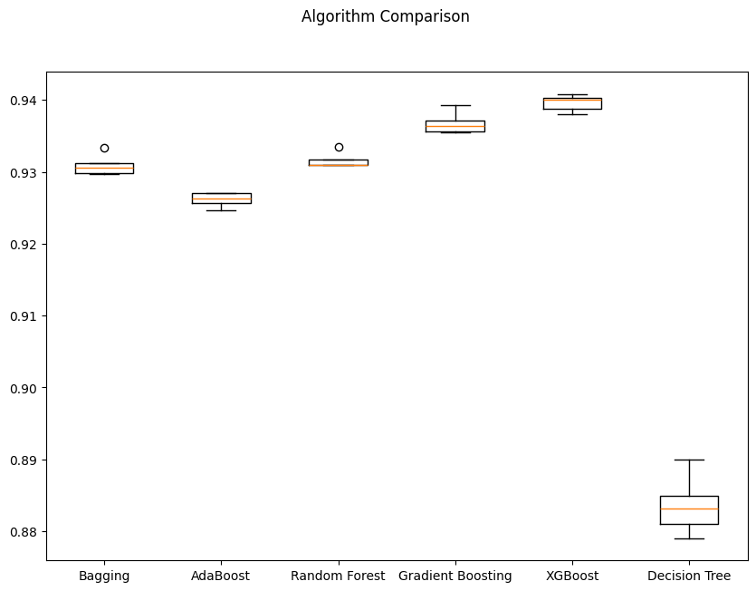

```python
# Plotting boxplots for CV scores of all models defined above
fig = plt.figure(figsize=(10, 7))

fig.suptitle("Algorithm Comparison")
ax = fig.add_subplot(111)

plt.boxplot(results1)
ax.set_xticklabels(names)

plt.show()
```

### Model Building with Oversampled data

```python
print("Before Oversampling, counts of label 'Yes' in training data : {}".format(sum(y_train == 1)))
print("Before Oversampling, counts of label 'No' in training data : {} \n".format(sum(y_train == 0)))

# Synthetic Minority Over Sampling Technique
sm = SMOTE(sampling_strategy=1, k_neighbors=5, random_state=1)
X_train_over, y_train_over = sm.fit_resample(X_train, y_train)
print("After Oversampling, counts of label 'Yes' in training data : {}".format(sum(y_train_over == 1)))
print("After Oversampling, counts of label 'No' in training data : {} \n".format(sum(y_train_over == 0)))

print("After Oversampling, the shape of train_X: {}".format(X_train_over.shape))
print("After Oversampling, the shape of train_y: {} \n".format(y_train_over.shape))
```

```
Before Oversampling, counts of label 'Yes' in training data : 3734
Before Oversampling, counts of label 'No' in training data : 40112

After Oversampling, counts of label 'Yes' in training data : 40112
After Oversampling, counts of label 'No' in training data : 40112

After Oversampling, the shape of train_X: (80224, 52)
After Oversampling, the shape of train_y: (80224,)
```

```python
print("Before Oversampling, counts of label 'Yes' in validation data : {}".format(sum(y_val == 1)))
print("Before Oversampling, counts of label 'No' in validation data : {} \n".format(sum(y_val == 0)))

X_val_over, y_val_over = sm.fit_resample(X_val, y_val)
print("After Oversampling, counts of label 'Yes' in validation data : {}".format(sum(y_val_over == 1)))
print("After Oversampling, counts of label 'No' in validation data : {} \n".format(sum(y_val_over == 0)))

print("After Oversampling, the shape of val_X: {}".format(X_val_over.shape))
print("After Oversampling, the shape of val_y: {} \n".format(y_val_over.shape))
```

```
Before Oversampling, counts of label 'Yes' in validation data : 234
Before Oversampling, counts of label 'No' in validation data : 2507

After Oversampling, counts of label 'Yes' in validation data : 2507
After Oversampling, counts of label 'No' in validation data : 2507

After Oversampling, the shape of val_X: (5014, 52)
After Oversampling, the shape of val_y: (5014,)
```

```python
print("Before Oversampling, counts of label 'Yes' in test data : {}".format(sum(y_test == 1)))
print("Before Oversampling, counts of label 'No' in test data : {} \n".format(sum(y_test == 0)))

X_test_over, y_test_over = sm.fit_resample(X_test, y_test)
print("After Oversampling, counts of label 'Yes' in test data : {}".format(sum(y_test_over == 1)))
print("After Oversampling, counts of label 'No' in test data : {} \n".format(sum(y_test_over == 0)))

print("After Oversampling, the shape of test_X: {}".format(X_test_over.shape))
print("After Oversampling, the shape of test_y: {} \n".format(y_test_over.shape))
```

```
Before Oversampling, counts of label 'Yes' in test data : 700
Before Oversampling, counts of label 'No' in test data : 7521

After Oversampling, counts of label 'Yes' in test data : 7521
After Oversampling, counts of label 'No' in test data : 7521

After Oversampling, the shape of test_X: (15042, 52)
After Oversampling, the shape of test_y: (15042,)
```

```python
# Code to build models on oversampled data
models_over = []  # Empty list to store all the models

# Appending models into the list
models_over.append(("Bagging", BaggingClassifier(random_state=1)))
models_over.append(("AdaBoost", AdaBoostClassifier(random_state=1)))
models_over.append(("Random Forest", RandomForestClassifier(random_state=1)))
models_over.append(("Gradient Boosting", GradientBoostingClassifier(random_state=1)))
models_over.append(("XGBoost", XGBClassifier(random_state=1)))
models_over.append(("Decision Tree", DecisionTreeClassifier(random_state=1)))

results1_over = []  # Empty list to store all model's CV scores
names_over = []  # Empty list to store name of the models

# loop through all models to get the mean cross validated score
print("\n" "Cross-Validation Cost with oversampled data :" "\n")
for name_over, model_over in models_over:
    kfold = StratifiedKFold(
        n_splits=5, shuffle=True, random_state=1
    )  # Setting number of splits equal to 5
    cv_result_over = cross_val_score(
        estimator=model_over, X=X_train_over, y=y_train_over, scoring=None, cv=kfold
    )
    results1_over.append(cv_result_over)
    names_over.append(name_over)
    print("{}: {}".format(name_over, cv_result_over.mean()))

# loop through all models to get the Training Data Performance
print("\n" "Training Performance with oversampled data :" "\n")
for name_over, model_over in models_over:
    model_over.fit(X_train_over, y_train_over)
    scores_over = recall_score(y_train_over, model_over.predict(X_train_over))
    print("{}: {}".format(name_over, scores_over))

# loop through all models to get the Validation Data Performance
print("\n" "Validation Performance with oversampled data :" "\n")
for name_over, model_over in models_over:
    model_over.fit(X_train_over, y_train_over)
    scores_val_over = recall_score(y_val_over, model_over.predict(X_val_over))
    print("{}: {}".format(name_over, scores_val_over))
```

```
Cross-Validation Cost with oversampled data :

Bagging: 0.9563347693189319
AdaBoost: 0.919325879229439
Random Forest: 0.9614579072399764
Gradient Boosting: 0.9382853113737782
XGBoost: 0.9634024623311136
Decision Tree: 0.9318283632444558

Training Performance with oversampled data :

Bagging: 0.9882080175508576
AdaBoost: 0.8567510969286
Random Forest: 0.999526326286398
Gradient Boosting: 0.891204627044276
XGBoost: 0.9339349820502593
Decision Tree: 0.9994764658954927

Validation Performance with oversampled data :

Bagging: 0.9274032708416434
AdaBoost: 0.8767451136816913
Random Forest: 0.9234144395692062
Gradient Boosting: 0.9034702832070204
XGBoost: 0.9313921021140805
Decision Tree: 0.9198244914240128
```

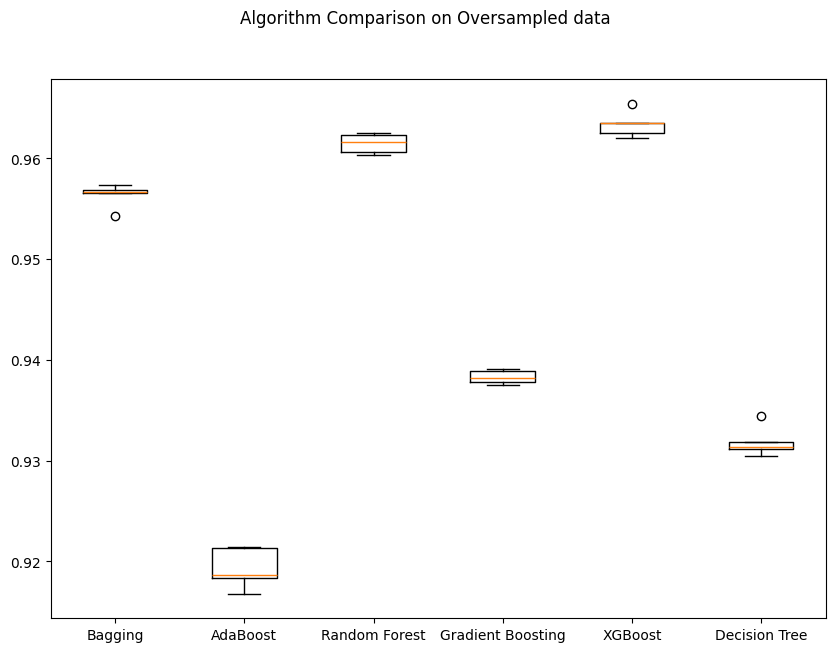

```python
# Plotting boxplots for CV scores of all models defined above on oversampled data
# Code to create boxplot to check model performance on oversampled data

fig = plt.figure(figsize=(10, 7))

fig.suptitle("Algorithm Comparison on Oversampled data")
ax = fig.add_subplot(111)

plt.boxplot(results1_over)
ax.set_xticklabels(names_over)

plt.show()
```

### Model Building with Undersampled data

```python
# Random undersampler for under sampling the data
rus = RandomUnderSampler(random_state=1, sampling_strategy=1)
X_train_un, y_train_un = rus.fit_resample(X_train, y_train)

print("Before Under Sampling, counts of label 'Yes' in training data : {}".format(sum(y_train == 1)))
print("Before Under Sampling, counts of label 'No' in training data : {} \n".format(sum(y_train == 0)))

print("After Under Sampling, counts of label 'Yes' in training data : {}".format(sum(y_train_un == 1)))
print("After Under Sampling, counts of label 'No' in training data : {} \n".format(sum(y_train_un == 0)))

print("After Under Sampling, the shape of train_X: {}".format(X_train_un.shape))
print("After Under Sampling, the shape of train_y: {} \n".format(y_train_un.shape))
```

```
Before Under Sampling, counts of label 'Yes' in training data : 3734
Before Under Sampling, counts of label 'No' in training data : 40112

After Under Sampling, counts of label 'Yes' in training data : 3734
After Under Sampling, counts of label 'No' in training data : 3734

After Under Sampling, the shape of train_X: (7468, 52)
After Under Sampling, the shape of train_y: (7468,)
```

```python
X_val_un, y_val_un = rus.fit_resample(X_val, y_val)

print("Before Under Sampling, counts of label 'Yes' in validation data : {}".format(sum(y_val == 1)))
print("Before Under Sampling, counts of label 'No' in validation data : {} \n".format(sum(y_val == 0)))

print("After Under Sampling, counts of label 'Yes' in validation data : {}".format(sum(y_val_un == 1)))
print("After Under Sampling, counts of label 'No' in validation data : {} \n".format(sum(y_val_un == 0)))

print("After Under Sampling, the shape of val_X: {}".format(X_val_un.shape))
print("After Under Sampling, the shape of val_y: {} \n".format(y_val_un.shape))
```

```
Before Under Sampling, counts of label 'Yes' in validation data : 234
Before Under Sampling, counts of label 'No' in validation data : 2507

After Under Sampling, counts of label 'Yes' in validation data : 234
After Under Sampling, counts of label 'No' in validation data : 234

After Under Sampling, the shape of val_X: (468, 52)
After Under Sampling, the shape of val_y: (468,)
```

```python
X_test_un, y_test_un = rus.fit_resample(X_test, y_test)

print("Before Under Sampling, counts of label 'Yes' in test data : {}".format(sum(y_test == 1)))
print("Before Under Sampling, counts of label 'No' in test data : {} \n".format(sum(y_test == 0)))

print("After Under Sampling, counts of label 'Yes' in test data : {}".format(sum(y_test_un == 1)))
print("After Under Sampling, counts of label 'No' in test data : {} \n".format(sum(y_test_un == 0)))

print("After Under Sampling, the shape of test_X: {}".format(X_test_un.shape))
print("After Under Sampling, the shape of test_y: {} \n".format(y_test_un.shape))
```

```
Before Under Sampling, counts of label 'Yes' in test data : 700
Before Under Sampling, counts of label 'No' in test data : 7521

After Under Sampling, counts of label 'Yes' in test data : 700
After Under Sampling, counts of label 'No' in test data : 700

After Under Sampling, the shape of test_X: (1400, 52)
After Under Sampling, the shape of test_y: (1400,)
```

```python
# Code to build models on Undersampled data
models_un = []  # Empty list to store all the models

# Appending models into the list
models_un.append(("Bagging", BaggingClassifier(random_state=1)))
models_un.append(("AdaBoost", AdaBoostClassifier(random_state=1)))
models_un.append(("Random Forest", RandomForestClassifier(random_state=1)))
models_un.append(("Gradient Boosting", GradientBoostingClassifier(random_state=1)))
models_un.append(("XGBoost", XGBClassifier(random_state=1)))
models_un.append(("Decision Tree", DecisionTreeClassifier(random_state=1)))

results1_un = []  # Empty list to store all model's CV scores
names_un = []  # Empty list to store name of the models

# loop through all models to get the mean cross validated score
print("\n" "Cross-Validation Cost with Undersampled data :" "\n")
for name_un, model_un in models_un:
    kfold = StratifiedKFold(
        n_splits=5, shuffle=True, random_state=1
    )  # Setting number of splits equal to 5
    cv_result_un = cross_val_score(
        estimator=model_un, X=X_train_un, y=y_train_un, scoring=None, cv=kfold
    )
    results1_un.append(cv_result_un)
    names_un.append(name_un)
    print("{}: {}".format(name_un, cv_result_un.mean()))

# loop through all models to get the Training Data Performance
print("\n" "Training Performance with Undersampled data :" "\n")
for name_un, model_un in models_un:
    model_un.fit(X_train_un, y_train_un)
    scores_un = recall_score(y_train_un, model_un.predict(X_train_un))
    print("{}: {}".format(name_un, scores_un))

# loop through all models to get the Validation Data Performance
print("\n" "Validation Performance with Undersampled data :" "\n")
for name_un, model_un in models_un:
    model_un.fit(X_train_un, y_train_un)
    scores_val_un = recall_score(y_val_un, model_un.predict(X_val_un))
    print("{}: {}".format(name_un, scores_val_un))
```

```
Cross-Validation Cost with Undersampled data :

Bagging: 0.6992487924459615
AdaBoost: 0.710633110696862
Random Forest: 0.7198702378166384
Gradient Boosting: 0.7206754232827717
XGBoost: 0.7162568559569826
Decision Tree: 0.6547936779491262

Training Performance with Undersampled data :

Bagging: 0.9678628816282807
AdaBoost: 0.6663095875736476
Random Forest: 0.9997321906802357
Gradient Boosting: 0.6333690412426353
XGBoost: 0.8186930905195501
Decision Tree: 0.9997321906802357

Validation Performance with Undersampled data :

Bagging: 0.6025641025641025
AdaBoost: 0.6752136752136753
Random Forest: 0.6495726495726496
Gradient Boosting: 0.6239316239316239
XGBoost: 0.6452991452991453
Decision Tree: 0.6837606837606838
```

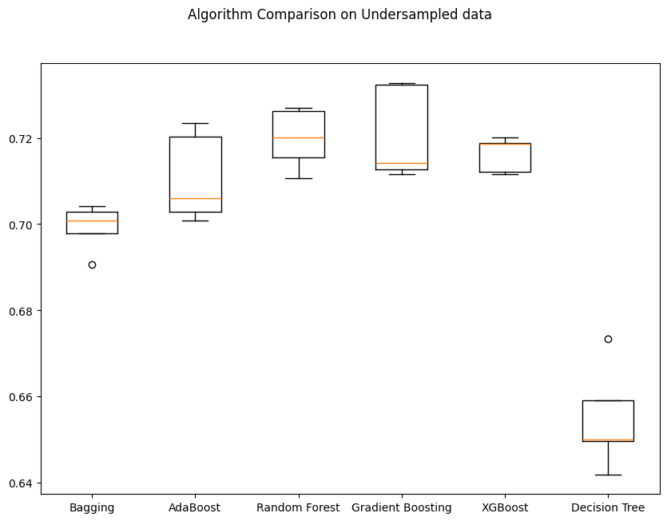

```python
# Plotting boxplots for CV scores of all models defined above on undersampled data
# Code to create boxplot to check model performance on undersampled data

fig = plt.figure(figsize=(10, 7))

fig.suptitle("Algorithm Comparison on Undersampled data")
ax = fig.add_subplot(111)

plt.boxplot(results1_un)
ax.set_xticklabels(names_un)

plt.show()
```

### HyperparameterTuning

#### Sample Parameter Grids

**Hyperparameter tuning can take a long time to run, so to avoid that time complexity - you can use the following grids, wherever required.**

- For Gradient Boosting:

```
param_grid = {
    "init": [AdaBoostClassifier(random_state=1),DecisionTreeClassifier(random_state=1)],
    "n_estimators": np.arange(75,150,25),
    "learning_rate": [0.1, 0.01, 0.2, 0.05, 1],
    "subsample":[0.5,0.7,1],
    "max_features":[0.5,0.7,1],
}
```

- For Adaboost:

```
param_grid = {
     "n_estimators": np.arange(10, 110, 10),
     "learning_rate": [0.1, 0.01, 0.2, 0.05, 1],
     "base_estimator": [
         DecisionTreeClassifier(max_depth=1, random_state=1),
         DecisionTreeClassifier(max_depth=2, random_state=1),
         DecisionTreeClassifier(max_depth=3, random_state=1),
    ]
}
```

- For Bagging Classifier:

```
param_grid = {
    'max_samples': [0.8,0.9,1],
    'max_features': [0.7,0.8,0.9],
    'n_estimators' : [30,50,70],
}
```

- For Random Forest:

```
param_grid = {
    "n_estimators": [200,250,300],
    "min_samples_leaf": np.arange(1, 4),
    "max_features": [np.arange(0.3, 0.6, 0.1),'sqrt'],
    "max_samples": np.arange(0.4, 0.7, 0.1)
}
```

- For Decision Trees:

```
param_grid = {
    'max_depth': np.arange(2,6),
    'min_samples_leaf': [1, 4, 7],
    'max_leaf_nodes' : [10, 15],
    'min_impurity_decrease': [0.0001,0.001]
}
```

- For XGBoost:

```
param_grid={
   'n_estimators':np.arange(50,300,50),
   'scale_pos_weight':[0,1,2,5,10],
   'learning_rate':[0.01,0.1,0.2,0.05],
   'gamma':[0,1,3,5],
   'subsample':[0.7,0.8,0.9,1]
}
```

# **Sample tuning method for Decision tree with original data**

```python
# defining model
Model = DecisionTreeClassifier(random_state=1)

# Parameter grid to pass in RandomSearchCV
param_grid = {'max_depth': np.arange(2,6),
              'min_samples_leaf': [1, 4, 7],
              'max_leaf_nodes' : [10,15],
              'min_impurity_decrease': [0.0001,0.001] }

# Type of scoring used to compare parameter combinations
scorer = 'f1_macro'

#Calling RandomizedSearchCV
randomized_cv = RandomizedSearchCV(estimator=Model, param_distributions=param_grid, n_iter=10, n_jobs = -1, scoring=scorer, cv=5, random_state=1)

#Fitting parameters in RandomizedSearchCV
randomized_cv.fit(X_train,y_train)

print("Best parameters are {} with CV score={}:" .format(randomized_cv.best_params_,randomized_cv.best_score_))
```

```
Best parameters are {'min_samples_leaf': 7, 'min_impurity_decrease': 0.0001, 'max_leaf_nodes': 15, 'max_depth': 5} with CV score=0.6115492686917057:
```

```python
# Creating new pipeline with best parameters
tuned_decisiontree = DecisionTreeClassifier(random_state=1,
                                             min_samples_leaf=randomized_cv.best_params_['min_samples_leaf'],
                                             min_impurity_decrease=randomized_cv.best_params_['min_impurity_decrease'],
                                             max_leaf_nodes=randomized_cv.best_params_['max_leaf_nodes'],
                                             max_depth=randomized_cv.best_params_['max_depth']);
tuned_decisiontree.fit(X_train, y_train)
```

```
DecisionTreeClassifier(max_depth=5, max_leaf_nodes=15,
                       min_impurity_decrease=0.0001, min_samples_leaf=7,
                       random_state=1)
```

```python
# Code to check the performance on training set
decisiontree_train = model_performance_classification_sklearn(tuned_decisiontree, X_train, y_train)
print(decisiontree_train)
```

```
   Accuracy  Recall  Precision    F1
0     0.925   0.130      0.899 0.228
```

```python
# Code to check the performance on validation set
decisiontree_val = model_performance_classification_sklearn(tuned_decisiontree, X_val, y_val)
print(decisiontree_val)
```

```
   Accuracy  Recall  Precision    F1
0     0.923   0.115      0.871 0.204
```

# **Sample tuning method for Decision tree with oversampled data**

```python
#Fitting parameters in RandomizedSearchCV
randomized_cv.fit(X_train_over,y_train_over)

print("Best parameters are {} with CV score={}:" .format(randomized_cv.best_params_,randomized_cv.best_score_))
```

```
Best parameters are {'min_samples_leaf': 7, 'min_impurity_decrease': 0.0001, 'max_leaf_nodes': 15, 'max_depth': 5} with CV score=0.7465297804810208:
```

```python
# Creating new pipeline with best parameters
tuned_decisiontree_over = DecisionTreeClassifier(random_state=1,
                                             min_samples_leaf=randomized_cv.best_params_['min_samples_leaf'],
                                             min_impurity_decrease=randomized_cv.best_params_['min_impurity_decrease'],
                                             max_leaf_nodes=randomized_cv.best_params_['max_leaf_nodes'],
                                             max_depth=randomized_cv.best_params_['max_depth']);
tuned_decisiontree_over.fit(X_train_over, y_train_over)
```

```
DecisionTreeClassifier(max_depth=5, max_leaf_nodes=15,
                       min_impurity_decrease=0.0001, min_samples_leaf=7,
                       random_state=1)
```

```python
# Code to check the performance on training set
decisiontree_over_train = model_performance_classification_sklearn(tuned_decisiontree_over, X_train_over, y_train_over)
print(decisiontree_over_train)
```

```
   Accuracy  Recall  Precision    F1
0     0.739   0.612      0.820 0.701
```

```python
# Code to check the performance on validation set
decisiontree_over_val = model_performance_classification_sklearn(tuned_decisiontree_over, X_val_over, y_val_over)
print(decisiontree_over_val)
```

```
   Accuracy  Recall  Precision    F1
0     0.740   0.618      0.818 0.704
```

# **Sample tuning method for Decision tree with undersampled data**

```python
# Parameter grid to pass in RandomSearchCV
param_grid = {'max_depth': np.arange(2,20),
              'min_samples_leaf': [1, 2, 5, 7],
              'max_leaf_nodes' : [5, 10,15],
              'min_impurity_decrease': [0.0001,0.001] }

#Calling RandomizedSearchCV
randomized_cv = RandomizedSearchCV(estimator=Model, param_distributions=param_grid, n_iter=10, n_jobs = -1, scoring=scorer, cv=5, random_state=1)

#Fitting parameters in RandomizedSearchCV
randomized_cv.fit(X_train_un,y_train_un)

print("Best parameters are {} with CV score={}:" .format(randomized_cv.best_params_,randomized_cv.best_score_))
```

```
Best parameters are {'min_samples_leaf': 1, 'min_impurity_decrease': 0.001, 'max_leaf_nodes': 15, 'max_depth': 11} with CV score=0.6856214316383575:
```

```python
# Creating new pipeline with best parameters
tuned_decisiontree_un = DecisionTreeClassifier(random_state=1,
                                             min_samples_leaf=randomized_cv.best_params_['min_samples_leaf'],
                                             min_impurity_decrease=randomized_cv.best_params_['min_impurity_decrease'],
                                             max_leaf_nodes=randomized_cv.best_params_['max_leaf_nodes'],
                                             max_depth=randomized_cv.best_params_['max_depth']);
tuned_decisiontree_un.fit(X_train_un, y_train_un)
```

```
DecisionTreeClassifier(max_depth=11, max_leaf_nodes=15,
                       min_impurity_decrease=0.001, random_state=1)
```

```python
# Code to check the performance on training set
decisiontree_un_train = model_performance_classification_sklearn(tuned_decisiontree_un, X_train_un, y_train_un)
print(decisiontree_un_train)
```

```
   Accuracy  Recall  Precision    F1
0     0.702   0.631      0.735 0.679
```

```python
# Code to check the performance on validation set
decisiontree_un_val = model_performance_classification_sklearn(tuned_decisiontree_un, X_val_un, y_val_un)
print(decisiontree_un_val)
```

```
   Accuracy  Recall  Precision    F1
0     0.692   0.624      0.723 0.670
```

# **Tuning AdaBoost using original data**

```python
%%time
# defining model
Model = AdaBoostClassifier(random_state=1)

# Parameter grid to pass in RandomSearchCV
param_grid = {
    "n_estimators": np.arange(10, 110, 10),
    "learning_rate": [0.1, 0.01, 0.2, 0.05, 1],
    "estimator": [
        DecisionTreeClassifier(max_depth=1, random_state=1),
        DecisionTreeClassifier(max_depth=2, random_state=1),
        DecisionTreeClassifier(max_depth=3, random_state=1),
    ],
}

# Type of scoring used to compare parameter combinations
scorer = 'f1_macro'

#Calling RandomizedSearchCV
randomized_cv = RandomizedSearchCV(estimator=Model, param_distributions=param_grid, n_jobs = -1, n_iter=50, scoring=scorer, cv=5, random_state=1)

#Fitting parameters in RandomizedSearchCV
randomized_cv.fit(X_train, y_train)

print("Best parameters are {} with CV score={}:" .format(randomized_cv.best_params_,randomized_cv.best_score_))
```

```
Best parameters are {'n_estimators': 100, 'learning_rate': 1, 'estimator': DecisionTreeClassifier(max_depth=2, random_state=1)} with CV score=0.7201309370846852:
CPU times: user 12.4 s, sys: 1.22 s, total: 13.7 s
Wall time: 11min 21s
```

```python
# Creating new pipeline with best parameters
tuned_adb1 = AdaBoostClassifier(random_state=1,
                                n_estimators=randomized_cv.best_params_['n_estimators'],
                                learning_rate=randomized_cv.best_params_['learning_rate'],
                                estimator=randomized_cv.best_params_['estimator']);
tuned_adb1.fit(X_train, y_train)
```

```
AdaBoostClassifier(estimator=DecisionTreeClassifier(max_depth=2,
                                                    random_state=1),
                   learning_rate=1, n_estimators=100, random_state=1)
```

```python
# Code to check the performance on training set
adb1_train = model_performance_classification_sklearn(tuned_adb1, X_train, y_train)
print(adb1_train)
```

```
   Accuracy  Recall  Precision    F1
0     0.940   0.330      0.903 0.484
```

```python
# Code to check the performance on validation set
adb1_val = model_performance_classification_sklearn(tuned_adb1, X_val, y_val)
print(adb1_val)
```

```
   Accuracy  Recall  Precision    F1
0     0.939   0.338      0.878 0.488
```

# **Tuning AdaBoost using Undersampled data**

```python
#Fitting undersampled data parameters in RandomizedSearchCV
randomized_cv.fit(X_train_un, y_train_un)

print("Best parameters are {} with CV score={}:" .format(randomized_cv.best_params_,randomized_cv.best_score_))
```

```
Best parameters are {'n_estimators': 90, 'learning_rate': 0.2, 'estimator': DecisionTreeClassifier(max_depth=2, random_state=1)} with CV score=0.7174660505173941:
```

```python
# Creating new pipeline with best parameters
tuned_adb2 = AdaBoostClassifier(random_state=1,
                                n_estimators=randomized_cv.best_params_['n_estimators'],
                                learning_rate=randomized_cv.best_params_['learning_rate'],
                                estimator=randomized_cv.best_params_['estimator']);
tuned_adb2.fit(X_train_un, y_train_un)
```

```
AdaBoostClassifier(estimator=DecisionTreeClassifier(max_depth=2,
                                                    random_state=1),
                   learning_rate=0.2, n_estimators=90, random_state=1)
```

```python
# Code to check the performance on training set
adb2_train = model_performance_classification_sklearn(tuned_adb2, X_train_un, y_train_un)
print(adb2_train)
```

```
   Accuracy  Recall  Precision    F1
0     0.731   0.631      0.788 0.701
```

```python
# Code to check the performance on validation set
adb2_val = model_performance_classification_sklearn(tuned_adb2, X_val_un, y_val_un)
print(adb2_val)
```

```
   Accuracy  Recall  Precision    F1
0     0.718   0.624      0.768 0.689
```

# **Tuning Gradient Boosting using original data**

```python
%%time

#defining model
Model = GradientBoostingClassifier(random_state=1)

#Parameter grid to pass in RandomSearchCV
param_grid = {
    "init": [AdaBoostClassifier(random_state=1),DecisionTreeClassifier(random_state=1)],
    "n_estimators": np.arange(75,150,25),
    "learning_rate": [0.1, 0.01, 0.2, 0.05, 1],
    "subsample":[0.5,0.7,1],
    "max_features":[0.5,0.7,1],
}

#Calling RandomizedSearchCV
randomized_cv = RandomizedSearchCV(estimator=Model, param_distributions=param_grid, n_iter=50, scoring=scorer, cv=5, random_state=1, n_jobs = -1)

#Fitting parameters in RandomizedSearchCV
randomized_cv.fit(X_train, y_train)

print("Best parameters are {} with CV score={}:" .format(randomized_cv.best_params_,randomized_cv.best_score_))
```

```
Best parameters are {'subsample': 0.7, 'n_estimators': 125, 'max_features': 0.7, 'learning_rate': 0.2, 'init': AdaBoostClassifier(random_state=1)} with CV score=0.7160697917445908:
CPU times: user 15.8 s, sys: 1.61 s, total: 17.4 s
Wall time: 15min 55s
```

```python
# Creating new pipeline with best parameters
tuned_gbm1 = GradientBoostingClassifier(
    max_features=randomized_cv.best_params_['max_features'],
    init=AdaBoostClassifier(random_state=1),
    random_state=1,
    learning_rate=randomized_cv.best_params_['learning_rate'],
    n_estimators=randomized_cv.best_params_['n_estimators'],
    subsample=randomized_cv.best_params_['subsample']
)

tuned_gbm1.fit(X_train, y_train)
```

```
GradientBoostingClassifier(init=AdaBoostClassifier(random_state=1),
                           learning_rate=0.2, max_features=0.7,
                           n_estimators=125, random_state=1, subsample=0.7)
```

```python
# Code to check the performance on training set
gbm1_train = model_performance_classification_sklearn(tuned_gbm1, X_train, y_train)
print(gbm1_train)
```

```
   Accuracy  Recall  Precision    F1
0     0.942   0.329      0.956 0.489
```

```python
# Code to check the performance on validation set
gbm1_val = model_performance_classification_sklearn(tuned_gbm1, X_val, y_val)
print(gbm1_val)
```

```
   Accuracy  Recall  Precision    F1
0     0.938   0.321      0.882 0.470
```

# **Tuning Gradient Boosting using undersampled data**

```python
%%time
#Fitting parameters in RandomizedSearchCV
randomized_cv.fit(X_train_un, y_train_un)

print("Best parameters are {} with CV score={}:" .format(randomized_cv.best_params_,randomized_cv.best_score_))
```

```
Best parameters are {'subsample': 0.5, 'n_estimators': 100, 'max_features': 0.7, 'learning_rate': 0.1, 'init': AdaBoostClassifier(random_state=1)} with CV score=0.722727268063283:
CPU times: user 4.01 s, sys: 503 ms, total: 4.51 s
Wall time: 2min 30s
```

```python
# Creating new pipeline with best parameters
tuned_gbm2 = GradientBoostingClassifier(
    max_features=randomized_cv.best_params_['max_features'],
    init=AdaBoostClassifier(random_state=1),
    random_state=1,
    learning_rate=randomized_cv.best_params_['learning_rate'],
    n_estimators=randomized_cv.best_params_['n_estimators'],
    subsample=randomized_cv.best_params_['subsample']
)

tuned_gbm2.fit(X_train_un, y_train_un)
```

```
GradientBoostingClassifier(init=AdaBoostClassifier(random_state=1),
                           max_features=0.7, random_state=1, subsample=0.5)
```

```python
# Code to check the performance on training set
gbm2_train = model_performance_classification_sklearn(tuned_gbm2, X_train_un, y_train_un)
print(gbm1_train)
```

```
   Accuracy  Recall  Precision    F1
0     0.942   0.329      0.956 0.489
```

```python
# Code to check the performance on validation set
gbm2_val = model_performance_classification_sklearn(tuned_gbm2, X_val_un, y_val_un)
print(gbm2_val)
```

```
   Accuracy  Recall  Precision    F1
0     0.729   0.645      0.774 0.704
```